# Selection of regression models from diabetes data (Linear Regression, Variable Selection, Ridge Regression and Lasso)

Xiang Wang, MAS student at The Pennsylvania State University

September 29, 2015

### Introduction

In this project, the diabetes dataset from R’s `lars` library or Efron et al. (2003) was used to fit five different models which include least square regression, best subset selection using BIC, best subset selection using 10-fold cross-validation, ridge and lasso methods. The evaluation of model fit and accuracy was measured by comparing the mean squared prediction errors and their standard errors.

### Analysis and Results

#### Data preparation and exploration

The data used here is part of R’s lars package. There are three variables and we are only interested in x and y. The prediction variable x is a variable matrix consisting of ten columns or variables (age, sex, bmi, map, tc, ldl, hdl, tch, ltg, glu); the response variable y consists of one column with 442 observations or patients. A random seed of 1306 was used to ensure the reproducibility of the project results. The data was then partitioned into two sets of data with a 3:1 ratio (training data, 75% roughly; testing data, 25% roughly).

#### Model building process

Each of the five models shares the same process of model building with the specific steps below.

- The same training data was used to generate each model using five methods.
- Then the models above were used to predict the response variable y using the test data.
- The mean squared prediction errors and their standard errors were calculated.

```r
library(lars)   # The data is available in R package “lars”
library(leaps)  # The package "leaps" was used to perform best subset selection by function regsubsets()
library(glmnet) # The package "glmnet" was used to perform Ridge Regression and Lasso
data(diabetes)
data.all <- data.frame(cbind(diabetes$x, y=diabetes$y))

# Partition the patients into two groups: training (75%) and test (25%)
n <- dim(data.all)[1]                      # sample size = 442
set.seed(1306)                             # set random number generator seed to enable repeatability of results
test <- sample(n, round(n/4))              # randomly sample 25% test
data.train <- data.all[-test,]
data.test <- data.all[test,]
x <- model.matrix(y~.,data=data.all)[,-1]  # define predictor matrix excl intercept col of 1s
x.train <- x[-test,]                       # define training predictor matrix
x.test <- x[test,]                         # define test predictor matrix
y <- data.all$y                            # define response variable
y.train <- y[-test]                        # define training response variable
y.test <- y[test]                          # define test response variable
n.train <- dim(data.train)[1]              # training sample size
n.test <- dim(data.test)[1]                # test sample size
```

#### Model 1: Least squares regression model using all ten predictors

R’s `lm` function was used to generate the least square model on all ten predictors. The following result shows the coefficient estimates and their corresponding p-values as well as the residuals plots for checking regression assumptions.

We can see that the four predictors (sex, bmi, map and ltg) are considered significant predictors with p-values smaller than 0.05. The plots also suggest that the residuals are roughly normally distributed. The multiple R-squared is 0.5213, and the adjusted R-squared is 0.5064. The F-statistic is 34.96 on 10 and 321 DF, p-value: < 2.2e-16. The mean squared predicted error is calculated as 3111.3 and its standard error is 361.1.

```r
OLS <- lm(y~., data.train); summary(OLS)   # fit the least squres model using training data
```

```
##
## Call:
## lm(formula = y ~ ., data = data.train)
##
## Residuals:
##      Min       1Q   Median       3Q      Max
## -155.726  -36.065   -2.758   35.039  151.509
##
## Coefficients:
##             Estimate Std. Error t value Pr(>|t|)
## (Intercept)  149.920      2.976  50.382  < 2e-16 ***
## age          -66.758     68.946  -0.968  0.33364
## sex         -304.651     69.847  -4.362 1.74e-05 ***
## bmi          518.663     76.573   6.773 6.01e-11 ***
## map          388.111     72.755   5.335 1.81e-07 ***
## tc          -815.268    537.549  -1.517  0.13034
## ldl          387.604    439.162   0.883  0.37811
## hdl          162.903    269.117   0.605  0.54539
## tch          323.832    186.803   1.734  0.08396 .
## ltg          673.620    206.888   3.256  0.00125 **
## glu           94.219     79.590   1.184  0.23737
## ---
## Signif. codes:  0 '***' 0.001 '**' 0.01 '*' 0.05 '.' 0.1 ' ' 1
##
## Residual standard error: 54.05 on 321 degrees of freedom
## Multiple R-squared:  0.5213, Adjusted R-squared:  0.5064
## F-statistic: 34.96 on 10 and 321 DF,  p-value: < 2.2e-16
```

```r
pred.OLS <- predict(OLS, data.test)        # predict the response using test data
mean((y.test-pred.OLS)^2)                  # calculate the mean prediction error (MSE)
```

```
## [1] 3111.265
```

```r
sd((y.test-pred.OLS)^2)/sqrt(n.test)       # calculate the standard error of MSE
```

```
## [1] 361.0908
```

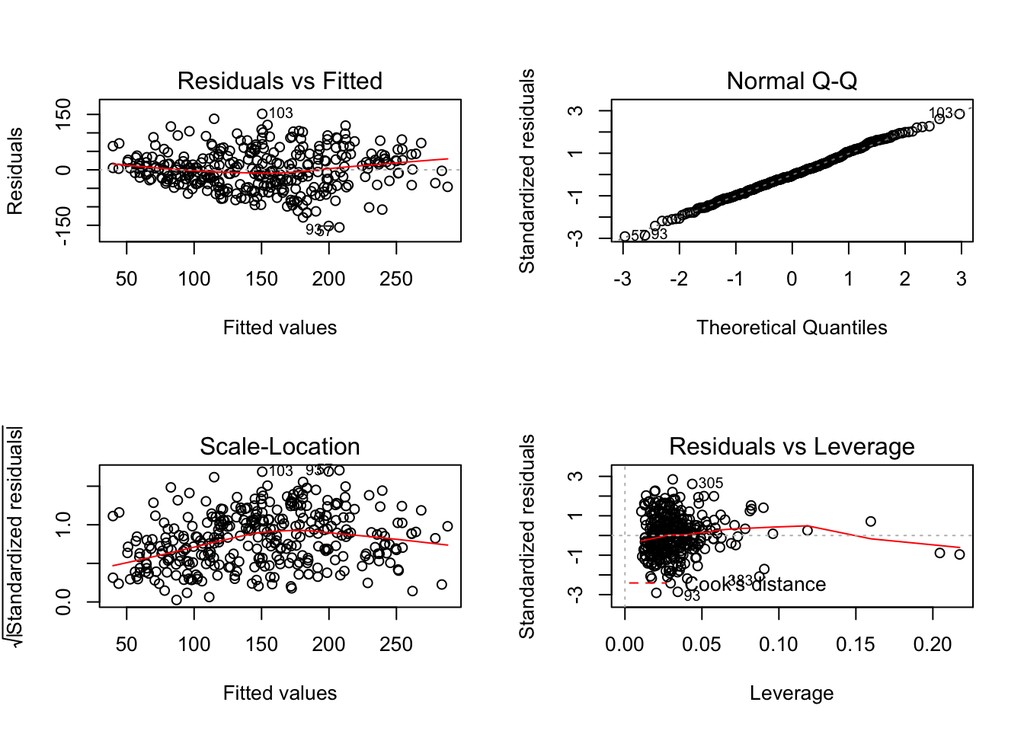

```r
par(mfrow=c(2,2)); plot(OLS)               # Check assumptions using residual and Q-Q plots
```

#### Model 2: Best subset selection using BIC to select the number of predictors

Since there is no built-in `predict()` function for regsubsets, function of `predict.regsubsets()` for best subset selection is defined using the code given in textbook. The regsubsets function (part of leaps package) was used to generate models with one through ten predictors. The model showing the lowest BIC (- 201.1) has six predictors (also shown in the figure on the right). Their coefficients and estimates are: sex (-306.0), bmi (538.8), map (389.1), tc (-379.0), tch (332.7) and ltg (527.6). From the predicted responses, the mean squared predicted error is calculated as 3095.5 and its standard error is computed to be 369.8.

```r
BIC <- regsubsets(y~., data=data.train, nvmax=10) # fit the best subset model using training data
summary(BIC)                                      # summarize the best subset model
```

```
## Subset selection object
## Call: regsubsets.formula(y ~ ., data = data.train, nvmax = 10)
## 10 Variables  (and intercept)
##     Forced in Forced out
## age     FALSE      FALSE
## sex     FALSE      FALSE
## bmi     FALSE      FALSE
## map     FALSE      FALSE
## tc      FALSE      FALSE
## ldl     FALSE      FALSE
## hdl     FALSE      FALSE
## tch     FALSE      FALSE
## ltg     FALSE      FALSE
## glu     FALSE      FALSE
## 1 subsets of each size up to 10
## Selection Algorithm: exhaustive
##           age sex bmi map tc  ldl hdl tch ltg glu
## 1  ( 1 )  " " " " "*" " " " " " " " " " " " " " "
## 2  ( 1 )  " " " " "*" " " " " " " " " " " "*" " "
## 3  ( 1 )  " " " " "*" "*" " " " " " " " " "*" " "
## 4  ( 1 )  " " " " "*" "*" "*" " " " " " " "*" " "
## 5  ( 1 )  " " "*" "*" "*" " " " " "*" " " "*" " "
## 6  ( 1 )  " " "*" "*" "*" "*" " " " " "*" "*" " "
## 7  ( 1 )  " " "*" "*" "*" "*" " " " " "*" "*" "*"
## 8  ( 1 )  "*" "*" "*" "*" "*" " " " " "*" "*" "*"
## 9  ( 1 )  "*" "*" "*" "*" "*" "*" " " "*" "*" "*"
## 10  ( 1 ) "*" "*" "*" "*" "*" "*" "*" "*" "*" "*"
```

```r
which.min(summary(BIC)$bic)                       # determine the number of variables with the lowest BIC value
```

```
## [1] 6
```

```r
coef(BIC, id=6)                                   # show the coefficient estimates for the model above
```

```
## (Intercept)         sex         bmi         map          tc         tch
##    150.1166   -306.0420    538.8274    389.0673   -379.0379    332.6735
##         ltg
##    527.5658
```

```r
# Create the function to use predict() with regsubsets
predict.regsubsets=function(object,newdata,id,...){
   form=as.formula(object$call[[2]])
   mat=model.matrix(form,newdata)
   coefi=coef(object,id=id)
   xvars=names(coefi)
   mat[,xvars]%*%coefi
}

pred.BIC <- predict(BIC, data.test, id=6)         # predict the response using test data
mean((y.test-pred.BIC)^2)                         # calculate the mean prediction error (MSE)
```

```
## [1] 3095.483
```

```r
sd((y.test-pred.BIC)^2)/sqrt(n.test)              # calculate the standard error of MSE
```

```
## [1] 369.7526
```

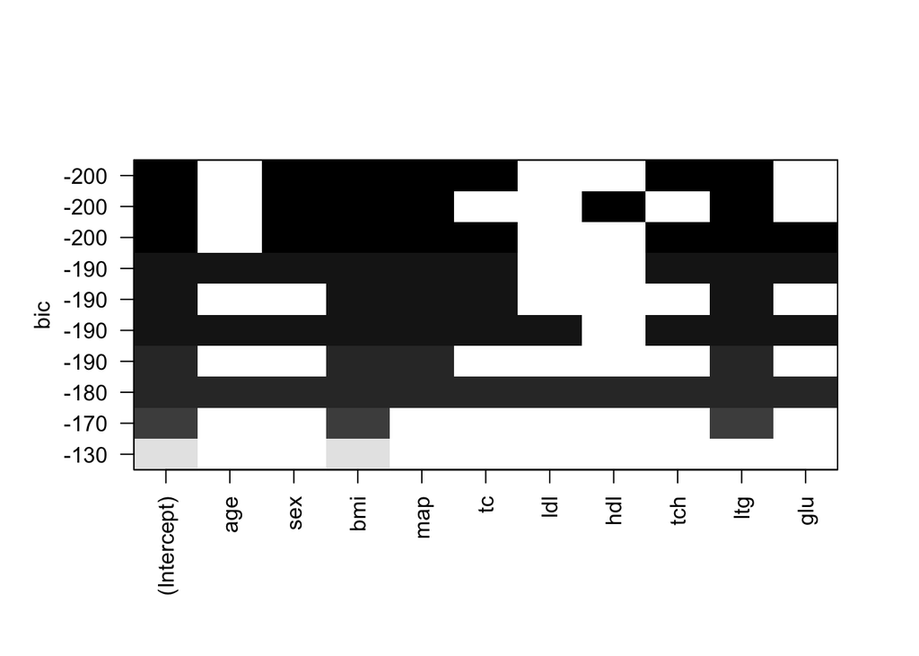

```r
plot(BIC, scale='bic')
```

#### Model 3: Best subset selection using 10-fold cross-validation to select the number of predictors

The `regsubsets` function (part of `leaps` package) was used to generate models with one through ten predictors. Training set is used to perform the 10-fold cross-validation to determine the number of predictors that would produces the lowest training mean cross-validation error. The model that had the lowest cross-validation error is a model with six predictors with the lowest mean cross-validation error (2979) (also shown in the figure on the right). This model’s coefficients and their estimates are: sex (-306.0), bmi (538.8), map (389.1), tc (- 379.0), tch (332.7) and ltg (527.6). From the predicted responses, the mean squared predicted error is calculated as 3095.5 and its standard error is computed to be 369.8.

```r
k=10; set.seed(1306)                                              # set k fold and random seed
folds <- sample(1:k, nrow(data.train), replace=TRUE)              # define each fold
cv.errors <- matrix(NA, k, 10, dimnames=list(NULL, paste(1:10)))  # define the matrix for CV errors
for(j in 1:k){
   best=regsubsets(y~., data=data.train[folds!=j,], nvmax=10)
   for(i in 1:10) {
     pred=predict(best,data.train[folds==j,], id=i)
     cv.errors[j, i]=mean((data.train$y[folds==j]-pred)^2)
   }
}
mean.cv.errors <- apply(cv.errors, 2, mean); mean.cv.errors      # calculate the mean CV error
```

```
##        1        2        3        4        5        6        7        8
## 3982.604 3420.948 3263.854 3306.494 3075.927 2978.907 3019.831 3005.795
##        9       10
## 3032.977 3022.442
```

```r
which.min(mean.cv.errors) # 6                                    # determine the number of variables with the lowest CV error
```

```
## 6
## 6
```

```r
best <- regsubsets(y~., data=data.train, nvmax=10)               # fit the best subset model using training data
coef(best, 6)                                                    # show the coefficient estimates for the model above
```

```
## (Intercept)         sex         bmi         map          tc         tch
##    150.1166   -306.0420    538.8274    389.0673   -379.0379    332.6735
##         ltg
##    527.5658
```

```r
pred.best <- predict(best,data.test, 6)                          # predict the response using test data
mean((y.test-pred.best)^2)                                       # calculate the mean prediction error (MSE)
```

```
## [1] 3095.483
```

```r
sd((y.test-pred.best)^2)/sqrt(n.test)                            # calculate the standard error of MSE
```

```
## [1] 369.7526
```

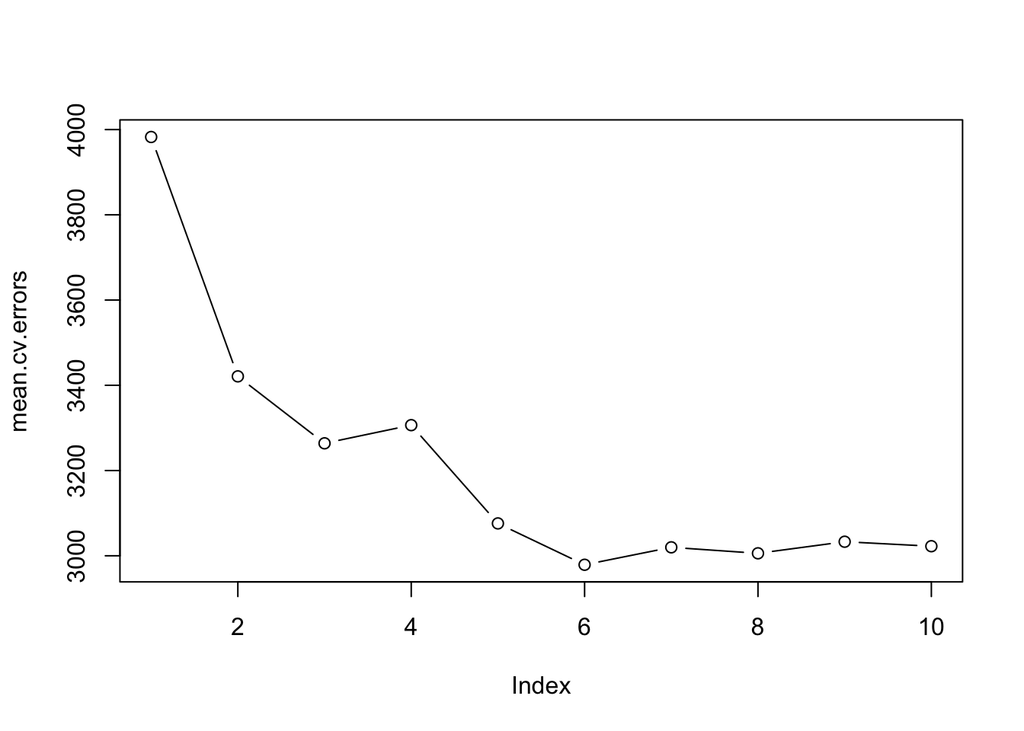

```r
plot(mean.cv.errors, type='b')
```

#### Model 4: Ridge regression using 10-fold cross-validation to select the largest value of λ such that the cross-validation error # is within 1 SE of the minimum

The `cv.glmnet` function (part of R `glmnet` package) was used to generate a model that is set to 10-fold CV and alpha=0 to determine the largest λ value with CV error within 1 SE of the minimum. The model obtained is also shown in the figure on the right.

```r
set.seed(1306)
cv.out <- cv.glmnet(x.train, y.train, alpha=0, nfolds=10)
bestλ <- cv.out$lambda.1se; bestλ
```

```
## [1] 41.67209
```

```r
ridge <- glmnet(x.train, y.train,alpha=0)
pred.ridge <- predict(ridge, s=bestλ, newx=x.test)
predict(ridge, type="coefficients", s=bestλ)[1:11, ]
```

```
## (Intercept)         age         sex         bmi         map          tc
##   149.99086   -11.25502  -156.90281   374.44565   264.86245   -32.09103
##         ldl         hdl         tch         ltg         glu
##   -66.97779  -173.82190   124.03502   307.72524   134.51753
```

```r
mean((y.test-pred.ridge)^2)
```

```
## [1] 3070.94
```

```r
sd((y.test-pred.ridge)^2)/sqrt(n.test)
```

```
## [1] 350.5565
```

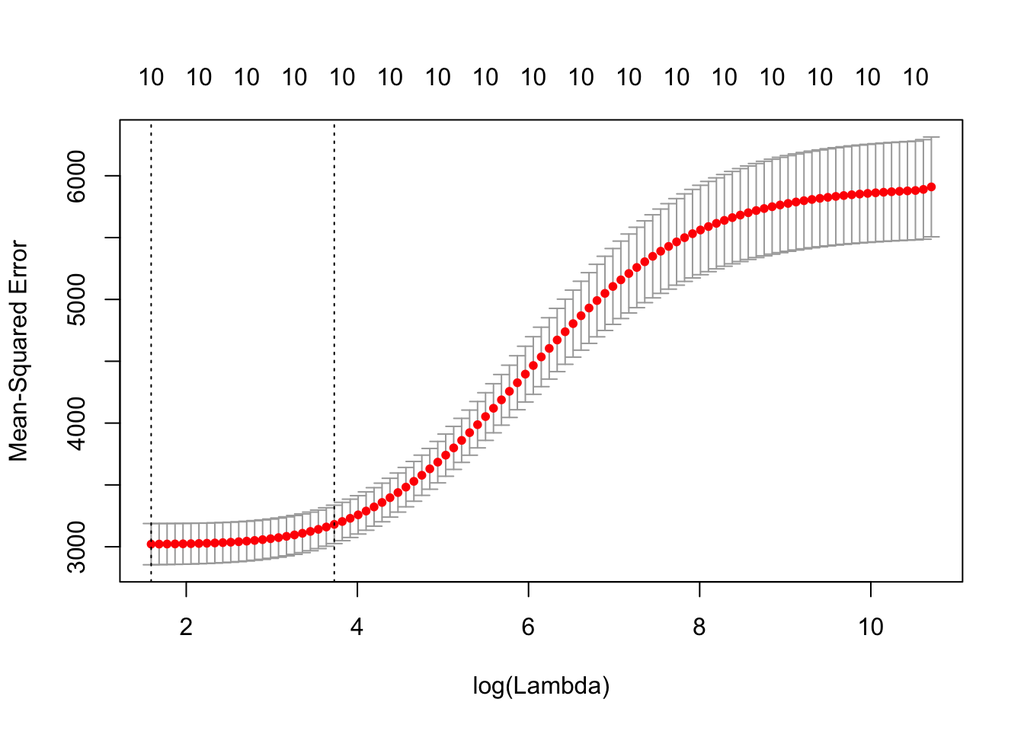

```r
plot(cv.out)
```

#### Model 5: Lasso regression using 10-fold cross-validation to select the largest value of λ such that the cross-validation error # is within 1 SE of the minimum

```r
set.seed(1306)
cv.out <- cv.glmnet(x.train, y.train, alpha=1, nfolds=10)
bestλ <- cv.out$lambda.1se; bestλ
```

```
## [1] 4.791278
```

```r
lasso <- glmnet(x.train, y.train, alpha =1)
pred.lasso <- predict(lasso, s=bestλ, newx=x.test, exact=T)
mean((y.test-pred.lasso)^2)
```

```
## [1] 2920.051
```

```r
sd((y.test-pred.lasso)^2)/sqrt(n.test)
```

```
## [1] 346.2286
```

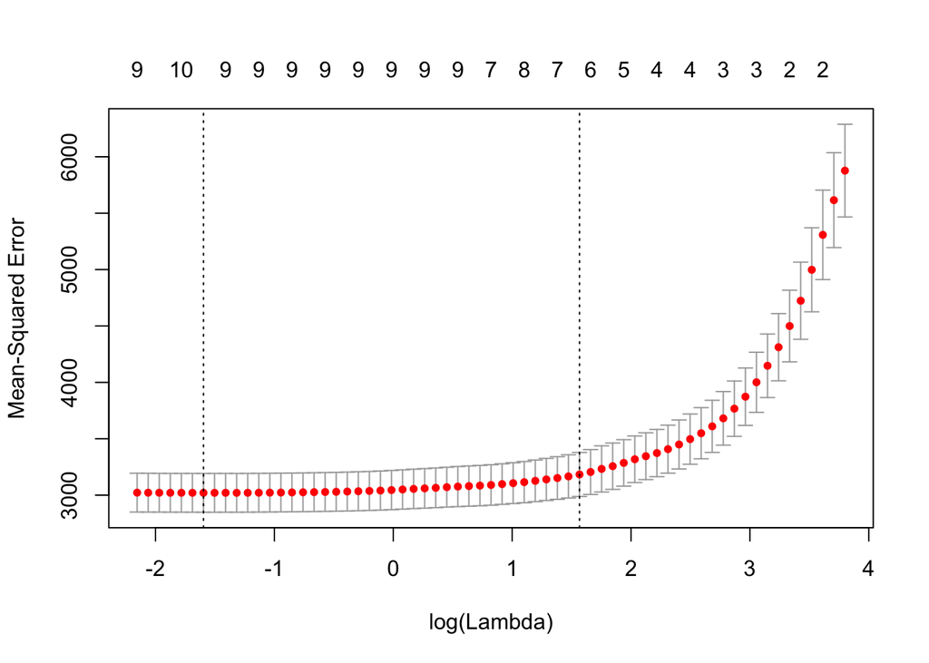

```r
plot(cv.out)
```

### Summary and Conclusion

In general, I think the mean squared prediction errors and their standard errors are fairly close to each other although they vary at some extent. From the points of model complexity and interpretation, BIC and 10-fold cross-validation of best subset models as well as well as the lasso model are the simplest or optimal models. Considering that the Lasso model had the smallest prediction error and standard error, it is the best model I prefer to.